# Risk Factor Analysis

## Outcome Variable

**Outcome Variable:** ever_stunted

## Predictor Variables

**Intervention Variable:** single

**Adjustment Set:**

- arm
- W_mage
- meducyrs
- feducyrs
- W_mhtcm
- W_mwtkg
- W_mbmi
- delta_W_mage
- delta_meducyrs
- delta_feducyrs
- delta_W_mhtcm
- delta_W_mwtkg
- delta_W_mbmi

## Stratifying Variables

The analysis was stratified on these variable(s):

- agecat
- studyid
- country

## Data Summary

| agecat | studyid | country | single | ever_stunted | n_cell | n |
| --- | --- | --- | --- | --- | --- | --- |
| 0-6 months | ki0047075b-MAL-ED | BANGLADESH | 0 | 0 | 217 | 265 |
| 0-6 months | ki0047075b-MAL-ED | BANGLADESH | 0 | 1 | 48 | 265 |
| 0-6 months | ki0047075b-MAL-ED | BRAZIL | 0 | 0 | 180 | 233 |
| 0-6 months | ki0047075b-MAL-ED | BRAZIL | 0 | 1 | 17 | 233 |
| 0-6 months | ki0047075b-MAL-ED | BRAZIL | 1 | 0 | 28 | 233 |
| 0-6 months | ki0047075b-MAL-ED | BRAZIL | 1 | 1 | 8 | 233 |
| 0-6 months | ki0047075b-MAL-ED | INDIA | 0 | 0 | 208 | 249 |
| 0-6 months | ki0047075b-MAL-ED | INDIA | 0 | 1 | 41 | 249 |
| 0-6 months | ki0047075b-MAL-ED | NEPAL | 0 | 0 | 212 | 240 |
| 0-6 months | ki0047075b-MAL-ED | NEPAL | 0 | 1 | 28 | 240 |
| 0-6 months | ki0047075b-MAL-ED | PERU | 0 | 0 | 238 | 303 |
| 0-6 months | ki0047075b-MAL-ED | PERU | 0 | 1 | 30 | 303 |
| 0-6 months | ki0047075b-MAL-ED | PERU | 1 | 0 | 28 | 303 |
| 0-6 months | ki0047075b-MAL-ED | PERU | 1 | 1 | 7 | 303 |
| 0-6 months | ki0047075b-MAL-ED | SOUTH AFRICA | 0 | 0 | 160 | 314 |
| 0-6 months | ki0047075b-MAL-ED | SOUTH AFRICA | 0 | 1 | 16 | 314 |
| 0-6 months | ki0047075b-MAL-ED | SOUTH AFRICA | 1 | 0 | 120 | 314 |
| 0-6 months | ki0047075b-MAL-ED | SOUTH AFRICA | 1 | 1 | 18 | 314 |
| 0-6 months | ki0047075b-MAL-ED | TANZANIA, UNITED REPUBLIC OF | 0 | 0 | 210 | 262 |
| 0-6 months | ki0047075b-MAL-ED | TANZANIA, UNITED REPUBLIC OF | 0 | 1 | 42 | 262 |
| 0-6 months | ki0047075b-MAL-ED | TANZANIA, UNITED REPUBLIC OF | 1 | 0 | 9 | 262 |
| 0-6 months | ki0047075b-MAL-ED | TANZANIA, UNITED REPUBLIC OF | 1 | 1 | 1 | 262 |
| 0-6 months | ki1066203-TanzaniaChild2 | TANZANIA, UNITED REPUBLIC OF | 0 | 0 | 2004 | 2375 |
| 0-6 months | ki1066203-TanzaniaChild2 | TANZANIA, UNITED REPUBLIC OF | 0 | 1 | 147 | 2375 |
| 0-6 months | ki1066203-TanzaniaChild2 | TANZANIA, UNITED REPUBLIC OF | 1 | 0 | 211 | 2375 |
| 0-6 months | ki1066203-TanzaniaChild2 | TANZANIA, UNITED REPUBLIC OF | 1 | 1 | 13 | 2375 |
| 0-6 months | ki1112895-Guatemala BSC | GUATEMALA | 0 | 0 | 187 | 265 |
| 0-6 months | ki1112895-Guatemala BSC | GUATEMALA | 0 | 1 | 51 | 265 |
| 0-6 months | ki1112895-Guatemala BSC | GUATEMALA | 1 | 0 | 15 | 265 |
| 0-6 months | ki1112895-Guatemala BSC | GUATEMALA | 1 | 1 | 12 | 265 |

[output cut: 118 more lines]

The following strata were considered:

- agecat: 0-24 months, studyid: ki0047075b-MAL-ED, country: BANGLADESH
- agecat: 0-24 months, studyid: ki0047075b-MAL-ED, country: BRAZIL
- agecat: 0-24 months, studyid: ki0047075b-MAL-ED, country: INDIA
- agecat: 0-24 months, studyid: ki0047075b-MAL-ED, country: NEPAL
- agecat: 0-24 months, studyid: ki0047075b-MAL-ED, country: PERU
- agecat: 0-24 months, studyid: ki0047075b-MAL-ED, country: SOUTH AFRICA
- agecat: 0-24 months, studyid: ki0047075b-MAL-ED, country: TANZANIA, UNITED REPUBLIC OF
- agecat: 0-24 months, studyid: ki1066203-TanzaniaChild2, country: TANZANIA, UNITED REPUBLIC OF
- agecat: 0-24 months, studyid: ki1112895-Guatemala BSC, country: GUATEMALA
- agecat: 0-24 months, studyid: ki1119695-PROBIT, country: BELARUS
- agecat: 0-24 months, studyid: ki1126311-ZVITAMBO, country: ZIMBABWE
- agecat: 0-24 months, studyid: ki1135781-COHORTS, country: GUATEMALA
- agecat: 0-24 months, studyid: ki1135781-COHORTS, country: INDIA
- agecat: 0-24 months, studyid: ki1135781-COHORTS, country: PHILIPPINES
- agecat: 0-6 months, studyid: ki0047075b-MAL-ED, country: BANGLADESH
- agecat: 0-6 months, studyid: ki0047075b-MAL-ED, country: BRAZIL
- agecat: 0-6 months, studyid: ki0047075b-MAL-ED, country: INDIA
- agecat: 0-6 months, studyid: ki0047075b-MAL-ED, country: NEPAL
- agecat: 0-6 months, studyid: ki0047075b-MAL-ED, country: PERU
- agecat: 0-6 months, studyid: ki0047075b-MAL-ED, country: SOUTH AFRICA
- agecat: 0-6 months, studyid: ki0047075b-MAL-ED, country: TANZANIA, UNITED REPUBLIC OF
- agecat: 0-6 months, studyid: ki1066203-TanzaniaChild2, country: TANZANIA, UNITED REPUBLIC OF
- agecat: 0-6 months, studyid: ki1112895-Guatemala BSC, country: GUATEMALA
- agecat: 0-6 months, studyid: ki1119695-PROBIT, country: BELARUS
- agecat: 0-6 months, studyid: ki1126311-ZVITAMBO, country: ZIMBABWE
- agecat: 0-6 months, studyid: ki1135781-COHORTS, country: GUATEMALA
- agecat: 0-6 months, studyid: ki1135781-COHORTS, country: INDIA
- agecat: 0-6 months, studyid: ki1135781-COHORTS, country: PHILIPPINES
- agecat: 6-24 months, studyid: ki0047075b-MAL-ED, country: BANGLADESH
- agecat: 6-24 months, studyid: ki0047075b-MAL-ED, country: BRAZIL
- agecat: 6-24 months, studyid: ki0047075b-MAL-ED, country: INDIA
- agecat: 6-24 months, studyid: ki0047075b-MAL-ED, country: NEPAL
- agecat: 6-24 months, studyid: ki0047075b-MAL-ED, country: PERU
- agecat: 6-24 months, studyid: ki0047075b-MAL-ED, country: SOUTH AFRICA
- agecat: 6-24 months, studyid: ki0047075b-MAL-ED, country: TANZANIA, UNITED REPUBLIC OF
- agecat: 6-24 months, studyid: ki1066203-TanzaniaChild2, country: TANZANIA, UNITED REPUBLIC OF
- agecat: 6-24 months, studyid: ki1112895-Guatemala BSC, country: GUATEMALA
- agecat: 6-24 months, studyid: ki1119695-PROBIT, country: BELARUS
- agecat: 6-24 months, studyid: ki1126311-ZVITAMBO, country: ZIMBABWE
- agecat: 6-24 months, studyid: ki1135781-COHORTS, country: GUATEMALA
- agecat: 6-24 months, studyid: ki1135781-COHORTS, country: INDIA
- agecat: 6-24 months, studyid: ki1135781-COHORTS, country: PHILIPPINES

## Methods Detail

We’re interested in the causal parameters $E[Y_a]$ for all values of $a \in \mathcal{A}$. These parameters represent the mean outcome if, possibly contrary to fact, we intervened to set all units to have $A=a$. Under the randomization and positivity assumptions, these are identified by the statistical parameters $\psi_a=E_W[E_{Y|A,W}(Y|A=a,W)]$. In addition, we’re interested in the mean of $Y$, $E[Y]$ under no intervention (the observed mean). We will estimate these parameters by using SuperLearner to fit the relevant likelihood factors – $E_{Y|A,W}(Y|A=a,W)$ and $p(A=a|W)$, and then updating our likelihood fit using a joint TMLE.

For unadjusted analyses ($W=\{\}$), initial likelihoods were estimated using Lrnr_glm to estimate the simple $E(Y|A)$ and Lrnr_mean to estimate $p(A)$. For adjusted analyses, a small library containing Lrnr_glmnet, Lrnr_xgboost, and Lrnr_mean was used.

Having estimated these parameters, we will then use the delta method to estimate relative risks and attributable risks relative to a prespecified baseline level of $A$.

[output not shown]

# Results Detail

## Results Plots

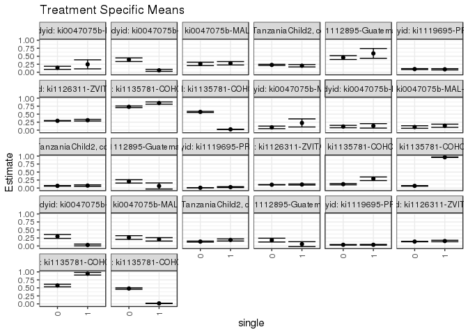

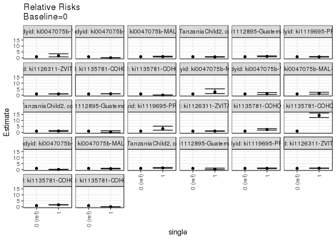

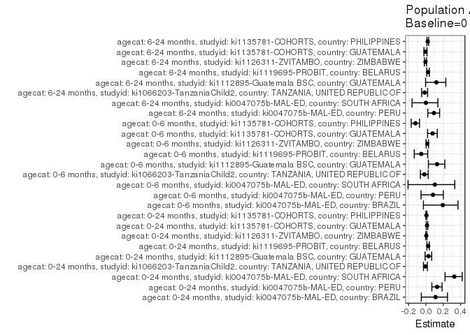

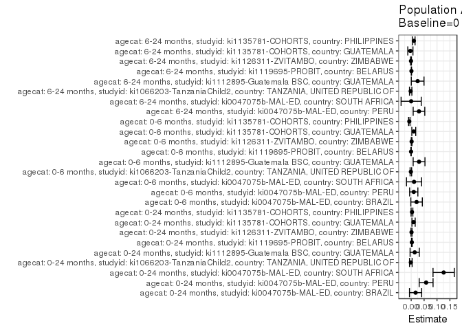

## Results Table

### Parameter: TSM

| agecat | studyid | country | intervention_level | baseline_level | estimate | ci_lower | ci_upper |
| --- | --- | --- | --- | --- | --- | --- | --- |
| 0-24 months | ki0047075b-MAL-ED | BRAZIL | 0 | NA | 0.1374784 | 0.0893776 | 0.1855793 |
| 0-24 months | ki0047075b-MAL-ED | BRAZIL | 1 | NA | 0.2464380 | 0.1053274 | 0.3875485 |
| 0-24 months | ki0047075b-MAL-ED | PERU | 0 | NA | 0.3909925 | 0.3341866 | 0.4477985 |
| 0-24 months | ki0047075b-MAL-ED | PERU | 1 | NA | 0.0588692 | 0.0276457 | 0.0900926 |
| 0-24 months | ki0047075b-MAL-ED | SOUTH AFRICA | 0 | NA | 0.2595110 | 0.2061281 | 0.3128939 |
| 0-24 months | ki0047075b-MAL-ED | SOUTH AFRICA | 1 | NA | 0.2796410 | 0.2265650 | 0.3327170 |
| 0-24 months | ki1066203-TanzaniaChild2 | TANZANIA, UNITED REPUBLIC OF | 0 | NA | 0.2283207 | 0.2106960 | 0.2459453 |
| 0-24 months | ki1066203-TanzaniaChild2 | TANZANIA, UNITED REPUBLIC OF | 1 | NA | 0.2028972 | 0.1662417 | 0.2395526 |
| 0-24 months | ki1112895-Guatemala BSC | GUATEMALA | 0 | NA | 0.4580659 | 0.3974209 | 0.5187109 |
| 0-24 months | ki1112895-Guatemala BSC | GUATEMALA | 1 | NA | 0.5878685 | 0.4347323 | 0.7410047 |
| 0-24 months | ki1119695-PROBIT | BELARUS | 0 | NA | 0.0980633 | 0.0822484 | 0.1138782 |
| 0-24 months | ki1119695-PROBIT | BELARUS | 1 | NA | 0.0912299 | 0.0710249 | 0.1114349 |
| 0-24 months | ki1126311-ZVITAMBO | ZIMBABWE | 0 | NA | 0.2913443 | 0.2836192 | 0.2990694 |
| 0-24 months | ki1126311-ZVITAMBO | ZIMBABWE | 1 | NA | 0.3101863 | 0.2846630 | 0.3357096 |
| 0-24 months | ki1135781-COHORTS | GUATEMALA | 0 | NA | 0.7289570 | 0.7035505 | 0.7543635 |
| 0-24 months | ki1135781-COHORTS | GUATEMALA | 1 | NA | 0.8461825 | 0.8113194 | 0.8810456 |
| 0-24 months | ki1135781-COHORTS | PHILIPPINES | 0 | NA | 0.5695306 | 0.5517983 | 0.5872629 |
| 0-24 months | ki1135781-COHORTS | PHILIPPINES | 1 | NA | 0.0241919 | 0.0184705 | 0.0299134 |
| 0-6 months | ki0047075b-MAL-ED | BRAZIL | 0 | NA | 0.0864170 | 0.0472966 | 0.1255373 |
| 0-6 months | ki0047075b-MAL-ED | BRAZIL | 1 | NA | 0.2246954 | 0.0983345 | 0.3510562 |
| 0-6 months | ki0047075b-MAL-ED | PERU | 0 | NA | 0.1121845 | 0.0749051 | 0.1494639 |
| 0-6 months | ki0047075b-MAL-ED | PERU | 1 | NA | 0.1335501 | 0.0644310 | 0.2026691 |
| 0-6 months | ki0047075b-MAL-ED | SOUTH AFRICA | 0 | NA | 0.0971991 | 0.0573552 | 0.1370430 |
| 0-6 months | ki0047075b-MAL-ED | SOUTH AFRICA | 1 | NA | 0.1365339 | 0.0866178 | 0.1864500 |
| 0-6 months | ki1066203-TanzaniaChild2 | TANZANIA, UNITED REPUBLIC OF | 0 | NA | 0.0685871 | 0.0579971 | 0.0791772 |
| 0-6 months | ki1066203-TanzaniaChild2 | TANZANIA, UNITED REPUBLIC OF | 1 | NA | 0.0764228 | 0.0545777 | 0.0982679 |
| 0-6 months | ki1112895-Guatemala BSC | GUATEMALA | 0 | NA | 0.2072549 | 0.1554364 | 0.2590733 |
| 0-6 months | ki1112895-Guatemala BSC | GUATEMALA | 1 | NA | 0.0646933 | -0.0308510 | 0.1602376 |
| 0-6 months | ki1119695-PROBIT | BELARUS | 0 | NA | 0.0095480 | 0.0064593 | 0.0126367 |
| 0-6 months | ki1119695-PROBIT | BELARUS | 1 | NA | 0.0291176 | 0.0148166 | 0.0434187 |
| 0-6 months | ki1126311-ZVITAMBO | ZIMBABWE | 0 | NA | 0.1036865 | 0.0984873 | 0.1088858 |
| 0-6 months | ki1126311-ZVITAMBO | ZIMBABWE | 1 | NA | 0.1105200 | 0.0928168 | 0.1282233 |
| 0-6 months | ki1135781-COHORTS | GUATEMALA | 0 | NA | 0.1213457 | 0.1004635 | 0.1422278 |
| 0-6 months | ki1135781-COHORTS | GUATEMALA | 1 | NA | 0.2905740 | 0.2341454 | 0.3470027 |
| 0-6 months | ki1135781-COHORTS | PHILIPPINES | 0 | NA | 0.0679709 | 0.0590219 | 0.0769200 |
| 0-6 months | ki1135781-COHORTS | PHILIPPINES | 1 | NA | 0.9626086 | 0.9559531 | 0.9692641 |
| 6-24 months | ki0047075b-MAL-ED | PERU | 0 | NA | 0.2973294 | 0.2359448 | 0.3587141 |
| 6-24 months | ki0047075b-MAL-ED | PERU | 1 | NA | 0.0304310 | 0.0025541 | 0.0583079 |
| 6-24 months | ki0047075b-MAL-ED | SOUTH AFRICA | 0 | NA | 0.2634795 | 0.2056427 | 0.3213163 |
| 6-24 months | ki0047075b-MAL-ED | SOUTH AFRICA | 1 | NA | 0.2068956 | 0.1539459 | 0.2598454 |
| 6-24 months | ki1066203-TanzaniaChild2 | TANZANIA, UNITED REPUBLIC OF | 0 | NA | 0.1367024 | 0.1203564 | 0.1530485 |
| 6-24 months | ki1066203-TanzaniaChild2 | TANZANIA, UNITED REPUBLIC OF | 1 | NA | 0.1880338 | 0.1553704 | 0.2206971 |
| 6-24 months | ki1112895-Guatemala BSC | GUATEMALA | 0 | NA | 0.1826344 | 0.1237493 | 0.2415194 |
| 6-24 months | ki1112895-Guatemala BSC | GUATEMALA | 1 | NA | 0.0572979 | -0.0185429 | 0.1331386 |
| 6-24 months | ki1119695-PROBIT | BELARUS | 0 | NA | 0.0371047 | 0.0279021 | 0.0463072 |
| 6-24 months | ki1119695-PROBIT | BELARUS | 1 | NA | 0.0369485 | 0.0254152 | 0.0484819 |
| 6-24 months | ki1126311-ZVITAMBO | ZIMBABWE | 0 | NA | 0.1369157 | 0.1297553 | 0.1440761 |
| 6-24 months | ki1126311-ZVITAMBO | ZIMBABWE | 1 | NA | 0.1543818 | 0.1315938 | 0.1771699 |
| 6-24 months | ki1135781-COHORTS | GUATEMALA | 0 | NA | 0.5736311 | 0.5329632 | 0.6142990 |
| 6-24 months | ki1135781-COHORTS | GUATEMALA | 1 | NA | 0.9421368 | 0.9024281 | 0.9818454 |
| 6-24 months | ki1135781-COHORTS | PHILIPPINES | 0 | NA | 0.4799537 | 0.4588999 | 0.5010074 |
| 6-24 months | ki1135781-COHORTS | PHILIPPINES | 1 | NA | 0.0157710 | 0.0100146 | 0.0215273 |

### Parameter: E(Y)

| agecat | studyid | country | intervention_level | baseline_level | estimate | ci_lower | ci_upper |
| --- | --- | --- | --- | --- | --- | --- | --- |
| 0-24 months | ki0047075b-MAL-ED | BRAZIL | NA | NA | 0.1545064 | 0.1079979 | 0.2010150 |
| 0-24 months | ki0047075b-MAL-ED | PERU | NA | NA | 0.4488449 | 0.3927492 | 0.5049406 |
| 0-24 months | ki0047075b-MAL-ED | SOUTH AFRICA | NA | NA | 0.3853503 | 0.3314343 | 0.4392663 |
| 0-24 months | ki1066203-TanzaniaChild2 | TANZANIA, UNITED REPUBLIC OF | NA | NA | 0.2269474 | 0.2100983 | 0.2437964 |
| 0-24 months | ki1112895-Guatemala BSC | GUATEMALA | NA | NA | 0.4716312 | 0.4132646 | 0.5299979 |
| 0-24 months | ki1119695-PROBIT | BELARUS | NA | NA | 0.1006096 | 0.0848963 | 0.1163228 |
| 0-24 months | ki1126311-ZVITAMBO | ZIMBABWE | NA | NA | 0.2926151 | 0.2850825 | 0.3001476 |
| 0-24 months | ki1135781-COHORTS | GUATEMALA | NA | NA | 0.7381939 | 0.7133826 | 0.7630052 |
| 0-24 months | ki1135781-COHORTS | PHILIPPINES | NA | NA | 0.5725646 | 0.5549120 | 0.5902172 |
| 0-6 months | ki0047075b-MAL-ED | BRAZIL | NA | NA | 0.1072961 | 0.0674717 | 0.1471206 |
| 0-6 months | ki0047075b-MAL-ED | PERU | NA | NA | 0.1221122 | 0.0851852 | 0.1590392 |
| 0-6 months | ki0047075b-MAL-ED | SOUTH AFRICA | NA | NA | 0.1082803 | 0.0738560 | 0.1427045 |
| 0-6 months | ki1066203-TanzaniaChild2 | TANZANIA, UNITED REPUBLIC OF | NA | NA | 0.0673684 | 0.0572854 | 0.0774514 |
| 0-6 months | ki1112895-Guatemala BSC | GUATEMALA | NA | NA | 0.2377358 | 0.1863852 | 0.2890865 |
| 0-6 months | ki1119695-PROBIT | BELARUS | NA | NA | 0.0090570 | 0.0059070 | 0.0122070 |
| 0-6 months | ki1126311-ZVITAMBO | ZIMBABWE | NA | NA | 0.1053384 | 0.1002517 | 0.1104250 |
| 0-6 months | ki1135781-COHORTS | GUATEMALA | NA | NA | 0.1314168 | 0.1101882 | 0.1526455 |
| 0-6 months | ki1135781-COHORTS | PHILIPPINES | NA | NA | 0.0606362 | 0.0521200 | 0.0691523 |
| 6-24 months | ki0047075b-MAL-ED | PERU | NA | NA | 0.3275109 | 0.2665942 | 0.3884276 |
| 6-24 months | ki0047075b-MAL-ED | SOUTH AFRICA | NA | NA | 0.2633929 | 0.2055812 | 0.3212045 |
| 6-24 months | ki1066203-TanzaniaChild2 | TANZANIA, UNITED REPUBLIC OF | NA | NA | 0.1347518 | 0.1191159 | 0.1503877 |
| 6-24 months | ki1112895-Guatemala BSC | GUATEMALA | NA | NA | 0.2076503 | 0.1487202 | 0.2665804 |
| 6-24 months | ki1119695-PROBIT | BELARUS | NA | NA | 0.0380298 | 0.0285924 | 0.0474672 |
| 6-24 months | ki1126311-ZVITAMBO | ZIMBABWE | NA | NA | 0.1361285 | 0.1291503 | 0.1431067 |
| 6-24 months | ki1135781-COHORTS | GUATEMALA | NA | NA | 0.5704467 | 0.5301958 | 0.6106977 |
| 6-24 months | ki1135781-COHORTS | PHILIPPINES | NA | NA | 0.4902050 | 0.4692872 | 0.5111228 |

### Parameter: RR

| agecat | studyid | country | intervention_level | baseline_level | estimate | ci_lower | ci_upper |
| --- | --- | --- | --- | --- | --- | --- | --- |
| 0-24 months | ki0047075b-MAL-ED | BRAZIL | 0 | 0 | 1.0000000 | 1.0000000 | 1.0000000 |
| 0-24 months | ki0047075b-MAL-ED | BRAZIL | 1 | 0 | 1.7925574 | 0.9171987 | 3.5033434 |
| 0-24 months | ki0047075b-MAL-ED | PERU | 0 | 0 | 1.0000000 | 1.0000000 | 1.0000000 |
| 0-24 months | ki0047075b-MAL-ED | PERU | 1 | 0 | 0.1505634 | 0.0849288 | 0.2669217 |
| 0-24 months | ki0047075b-MAL-ED | SOUTH AFRICA | 0 | 0 | 1.0000000 | 1.0000000 | 1.0000000 |
| 0-24 months | ki0047075b-MAL-ED | SOUTH AFRICA | 1 | 0 | 1.0775691 | 0.8103867 | 1.4328407 |
| 0-24 months | ki1066203-TanzaniaChild2 | TANZANIA, UNITED REPUBLIC OF | 0 | 0 | 1.0000000 | 1.0000000 | 1.0000000 |
| 0-24 months | ki1066203-TanzaniaChild2 | TANZANIA, UNITED REPUBLIC OF | 1 | 0 | 0.8886500 | 0.7311476 | 1.0800813 |
| 0-24 months | ki1112895-Guatemala BSC | GUATEMALA | 0 | 0 | 1.0000000 | 1.0000000 | 1.0000000 |
| 0-24 months | ki1112895-Guatemala BSC | GUATEMALA | 1 | 0 | 1.2833710 | 0.9675905 | 1.7022090 |
| 0-24 months | ki1119695-PROBIT | BELARUS | 0 | 0 | 1.0000000 | 1.0000000 | 1.0000000 |
| 0-24 months | ki1119695-PROBIT | BELARUS | 1 | 0 | 0.9303166 | 0.7383908 | 1.1721285 |
| 0-24 months | ki1126311-ZVITAMBO | ZIMBABWE | 0 | 0 | 1.0000000 | 1.0000000 | 1.0000000 |
| 0-24 months | ki1126311-ZVITAMBO | ZIMBABWE | 1 | 0 | 1.0646726 | 0.9768966 | 1.1603355 |
| 0-24 months | ki1135781-COHORTS | GUATEMALA | 0 | 0 | 1.0000000 | 1.0000000 | 1.0000000 |
| 0-24 months | ki1135781-COHORTS | GUATEMALA | 1 | 0 | 1.1608126 | 1.1007834 | 1.2241154 |
| 0-24 months | ki1135781-COHORTS | PHILIPPINES | 0 | 0 | 1.0000000 | 1.0000000 | 1.0000000 |
| 0-24 months | ki1135781-COHORTS | PHILIPPINES | 1 | 0 | 0.0424769 | 0.0334362 | 0.0539622 |
| 0-6 months | ki0047075b-MAL-ED | BRAZIL | 0 | 0 | 1.0000000 | 1.0000000 | 1.0000000 |
| 0-6 months | ki0047075b-MAL-ED | BRAZIL | 1 | 0 | 2.6001304 | 1.2741605 | 5.3059862 |
| 0-6 months | ki0047075b-MAL-ED | PERU | 0 | 0 | 1.0000000 | 1.0000000 | 1.0000000 |
| 0-6 months | ki0047075b-MAL-ED | PERU | 1 | 0 | 1.1904501 | 0.6452129 | 2.1964398 |
| 0-6 months | ki0047075b-MAL-ED | SOUTH AFRICA | 0 | 0 | 1.0000000 | 1.0000000 | 1.0000000 |
| 0-6 months | ki0047075b-MAL-ED | SOUTH AFRICA | 1 | 0 | 1.4046832 | 0.8130075 | 2.4269579 |
| 0-6 months | ki1066203-TanzaniaChild2 | TANZANIA, UNITED REPUBLIC OF | 0 | 0 | 1.0000000 | 1.0000000 | 1.0000000 |
| 0-6 months | ki1066203-TanzaniaChild2 | TANZANIA, UNITED REPUBLIC OF | 1 | 0 | 1.1142439 | 0.8059052 | 1.5405528 |
| 0-6 months | ki1112895-Guatemala BSC | GUATEMALA | 0 | 0 | 1.0000000 | 1.0000000 | 1.0000000 |
| 0-6 months | ki1112895-Guatemala BSC | GUATEMALA | 1 | 0 | 0.3121438 | 0.0697032 | 1.3978372 |
| 0-6 months | ki1119695-PROBIT | BELARUS | 0 | 0 | 1.0000000 | 1.0000000 | 1.0000000 |
| 0-6 months | ki1119695-PROBIT | BELARUS | 1 | 0 | 3.0496032 | 1.8007722 | 5.1644954 |
| 0-6 months | ki1126311-ZVITAMBO | ZIMBABWE | 0 | 0 | 1.0000000 | 1.0000000 | 1.0000000 |
| 0-6 months | ki1126311-ZVITAMBO | ZIMBABWE | 1 | 0 | 1.0659053 | 0.9014603 | 1.2603484 |
| 0-6 months | ki1135781-COHORTS | GUATEMALA | 0 | 0 | 1.0000000 | 1.0000000 | 1.0000000 |
| 0-6 months | ki1135781-COHORTS | GUATEMALA | 1 | 0 | 2.3945972 | 1.8567010 | 3.0883248 |
| 0-6 months | ki1135781-COHORTS | PHILIPPINES | 0 | 0 | 1.0000000 | 1.0000000 | 1.0000000 |
| 0-6 months | ki1135781-COHORTS | PHILIPPINES | 1 | 0 | 14.1620638 | 12.4019542 | 16.1719717 |
| 6-24 months | ki0047075b-MAL-ED | PERU | 0 | 0 | 1.0000000 | 1.0000000 | 1.0000000 |
| 6-24 months | ki0047075b-MAL-ED | PERU | 1 | 0 | 0.1023477 | 0.0393128 | 0.2664538 |
| 6-24 months | ki0047075b-MAL-ED | SOUTH AFRICA | 0 | 0 | 1.0000000 | 1.0000000 | 1.0000000 |
| 6-24 months | ki0047075b-MAL-ED | SOUTH AFRICA | 1 | 0 | 0.7852437 | 0.5608803 | 1.0993569 |
| 6-24 months | ki1066203-TanzaniaChild2 | TANZANIA, UNITED REPUBLIC OF | 0 | 0 | 1.0000000 | 1.0000000 | 1.0000000 |
| 6-24 months | ki1066203-TanzaniaChild2 | TANZANIA, UNITED REPUBLIC OF | 1 | 0 | 1.3754967 | 1.1166702 | 1.6943152 |
| 6-24 months | ki1112895-Guatemala BSC | GUATEMALA | 0 | 0 | 1.0000000 | 1.0000000 | 1.0000000 |
| 6-24 months | ki1112895-Guatemala BSC | GUATEMALA | 1 | 0 | 0.3137300 | 0.0807807 | 1.2184413 |
| 6-24 months | ki1119695-PROBIT | BELARUS | 0 | 0 | 1.0000000 | 1.0000000 | 1.0000000 |
| 6-24 months | ki1119695-PROBIT | BELARUS | 1 | 0 | 0.9957917 | 0.7304317 | 1.3575549 |
| 6-24 months | ki1126311-ZVITAMBO | ZIMBABWE | 0 | 0 | 1.0000000 | 1.0000000 | 1.0000000 |
| 6-24 months | ki1126311-ZVITAMBO | ZIMBABWE | 1 | 0 | 1.1275682 | 0.9644005 | 1.3183424 |
| 6-24 months | ki1135781-COHORTS | GUATEMALA | 0 | 0 | 1.0000000 | 1.0000000 | 1.0000000 |
| 6-24 months | ki1135781-COHORTS | GUATEMALA | 1 | 0 | 1.6424087 | 1.5125196 | 1.7834522 |
| 6-24 months | ki1135781-COHORTS | PHILIPPINES | 0 | 0 | 1.0000000 | 1.0000000 | 1.0000000 |
| 6-24 months | ki1135781-COHORTS | PHILIPPINES | 1 | 0 | 0.0328593 | 0.0226783 | 0.0476109 |

### Parameter: PAR

| agecat | studyid | country | intervention_level | baseline_level | estimate | ci_lower | ci_upper |
| --- | --- | --- | --- | --- | --- | --- | --- |
| 0-24 months | ki0047075b-MAL-ED | BRAZIL | 0 | NA | 0.0170280 | -0.0065760 | 0.0406320 |
| 0-24 months | ki0047075b-MAL-ED | PERU | 0 | NA | 0.0578523 | 0.0309758 | 0.0847289 |
| 0-24 months | ki0047075b-MAL-ED | SOUTH AFRICA | 0 | NA | 0.1258393 | 0.0845868 | 0.1670919 |
| 0-24 months | ki1066203-TanzaniaChild2 | TANZANIA, UNITED REPUBLIC OF | 0 | NA | -0.0013733 | -0.0064333 | 0.0036867 |
| 0-24 months | ki1112895-Guatemala BSC | GUATEMALA | 0 | NA | 0.0135653 | -0.0043302 | 0.0314609 |
| 0-24 months | ki1119695-PROBIT | BELARUS | 0 | NA | 0.0025463 | 0.0012310 | 0.0038615 |
| 0-24 months | ki1126311-ZVITAMBO | ZIMBABWE | 0 | NA | 0.0012708 | -0.0006966 | 0.0032382 |
| 0-24 months | ki1135781-COHORTS | GUATEMALA | 0 | NA | 0.0092368 | 0.0030025 | 0.0154712 |
| 0-24 months | ki1135781-COHORTS | PHILIPPINES | 0 | NA | 0.0030340 | -0.0003500 | 0.0064180 |
| 0-6 months | ki0047075b-MAL-ED | BRAZIL | 0 | NA | 0.0208792 | -0.0013954 | 0.0431538 |
| 0-6 months | ki0047075b-MAL-ED | PERU | 0 | NA | 0.0099277 | -0.0060381 | 0.0258935 |
| 0-6 months | ki0047075b-MAL-ED | SOUTH AFRICA | 0 | NA | 0.0110812 | -0.0182640 | 0.0404264 |
| 0-6 months | ki1066203-TanzaniaChild2 | TANZANIA, UNITED REPUBLIC OF | 0 | NA | -0.0012187 | -0.0042457 | 0.0018083 |
| 0-6 months | ki1112895-Guatemala BSC | GUATEMALA | 0 | NA | 0.0304810 | 0.0076043 | 0.0533576 |
| 0-6 months | ki1119695-PROBIT | BELARUS | 0 | NA | -0.0004910 | -0.0011409 | 0.0001589 |
| 0-6 months | ki1126311-ZVITAMBO | ZIMBABWE | 0 | NA | 0.0016519 | 0.0002195 | 0.0030842 |
| 0-6 months | ki1135781-COHORTS | GUATEMALA | 0 | NA | 0.0100711 | 0.0025418 | 0.0176005 |
| 0-6 months | ki1135781-COHORTS | PHILIPPINES | 0 | NA | -0.0073347 | -0.0100619 | -0.0046075 |
| 6-24 months | ki0047075b-MAL-ED | PERU | 0 | NA | 0.0301815 | 0.0076615 | 0.0527015 |
| 6-24 months | ki0047075b-MAL-ED | SOUTH AFRICA | 0 | NA | -0.0000866 | -0.0391250 | 0.0389517 |
| 6-24 months | ki1066203-TanzaniaChild2 | TANZANIA, UNITED REPUBLIC OF | 0 | NA | -0.0019507 | -0.0065834 | 0.0026820 |
| 6-24 months | ki1112895-Guatemala BSC | GUATEMALA | 0 | NA | 0.0250159 | 0.0003669 | 0.0496649 |
| 6-24 months | ki1119695-PROBIT | BELARUS | 0 | NA | 0.0009251 | 0.0003161 | 0.0015341 |
| 6-24 months | ki1126311-ZVITAMBO | ZIMBABWE | 0 | NA | -0.0007873 | -0.0025299 | 0.0009553 |
| 6-24 months | ki1135781-COHORTS | GUATEMALA | 0 | NA | -0.0031844 | -0.0131897 | 0.0068209 |
| 6-24 months | ki1135781-COHORTS | PHILIPPINES | 0 | NA | 0.0102514 | 0.0055383 | 0.0149644 |

### Parameter: PAF

| agecat | studyid | country | intervention_level | baseline_level | estimate | ci_lower | ci_upper |
| --- | --- | --- | --- | --- | --- | --- | --- |
| 0-24 months | ki0047075b-MAL-ED | BRAZIL | 0 | NA | 0.1102090 | -0.0534230 | 0.2484235 |
| 0-24 months | ki0047075b-MAL-ED | PERU | 0 | NA | 0.1288916 | 0.0682737 | 0.1855658 |
| 0-24 months | ki0047075b-MAL-ED | SOUTH AFRICA | 0 | NA | 0.3265582 | 0.2206239 | 0.4180938 |
| 0-24 months | ki1066203-TanzaniaChild2 | TANZANIA, UNITED REPUBLIC OF | 0 | NA | -0.0060511 | -0.0285976 | 0.0160011 |
| 0-24 months | ki1112895-Guatemala BSC | GUATEMALA | 0 | NA | 0.0287626 | -0.0100188 | 0.0660549 |
| 0-24 months | ki1119695-PROBIT | BELARUS | 0 | NA | 0.0253085 | 0.0114186 | 0.0390032 |
| 0-24 months | ki1126311-ZVITAMBO | ZIMBABWE | 0 | NA | 0.0043428 | -0.0024009 | 0.0110411 |
| 0-24 months | ki1135781-COHORTS | GUATEMALA | 0 | NA | 0.0125128 | 0.0040329 | 0.0209205 |
| 0-24 months | ki1135781-COHORTS | PHILIPPINES | 0 | NA | 0.0052990 | -0.0006193 | 0.0111822 |
| 0-6 months | ki0047075b-MAL-ED | BRAZIL | 0 | NA | 0.1945939 | -0.0291691 | 0.3697062 |
| 0-6 months | ki0047075b-MAL-ED | PERU | 0 | NA | 0.0812996 | -0.0563513 | 0.2010136 |
| 0-6 months | ki0047075b-MAL-ED | SOUTH AFRICA | 0 | NA | 0.1023381 | -0.2066318 | 0.3321932 |
| 0-6 months | ki1066203-TanzaniaChild2 | TANZANIA, UNITED REPUBLIC OF | 0 | NA | -0.0180905 | -0.0640528 | 0.0258865 |
| 0-6 months | ki1112895-Guatemala BSC | GUATEMALA | 0 | NA | 0.1282136 | 0.0282918 | 0.2178603 |
| 0-6 months | ki1119695-PROBIT | BELARUS | 0 | NA | -0.0542127 | -0.1348359 | 0.0206827 |
| 0-6 months | ki1126311-ZVITAMBO | ZIMBABWE | 0 | NA | 0.0156814 | 0.0020149 | 0.0291608 |
| 0-6 months | ki1135781-COHORTS | GUATEMALA | 0 | NA | 0.0766352 | 0.0190589 | 0.1308320 |
| 0-6 months | ki1135781-COHORTS | PHILIPPINES | 0 | NA | -0.1209631 | -0.1700435 | -0.0739416 |
| 6-24 months | ki0047075b-MAL-ED | PERU | 0 | NA | 0.0921542 | 0.0214528 | 0.1577472 |
| 6-24 months | ki0047075b-MAL-ED | SOUTH AFRICA | 0 | NA | -0.0003290 | -0.1601134 | 0.1374481 |
| 6-24 months | ki1066203-TanzaniaChild2 | TANZANIA, UNITED REPUBLIC OF | 0 | NA | -0.0144761 | -0.0494720 | 0.0193529 |
| 6-24 months | ki1112895-Guatemala BSC | GUATEMALA | 0 | NA | 0.1204714 | -0.0039740 | 0.2294915 |
| 6-24 months | ki1119695-PROBIT | BELARUS | 0 | NA | 0.0243266 | 0.0096220 | 0.0388129 |
| 6-24 months | ki1126311-ZVITAMBO | ZIMBABWE | 0 | NA | -0.0057832 | -0.0186753 | 0.0069458 |
| 6-24 months | ki1135781-COHORTS | GUATEMALA | 0 | NA | -0.0055823 | -0.0233130 | 0.0118412 |
| 6-24 months | ki1135781-COHORTS | PHILIPPINES | 0 | NA | 0.0209124 | 0.0112843 | 0.0304467 |